# Boosting: AdaBoost

Alípio Jorge

March 2021

# Boosting

- **Boosting** is one of the most important **ensemble** methods
  - Probably **the** most important
- **Other** ensemble methods:
  - Bagging $\checkmark$
  - Random Forest $\checkmark$
  - Stacking
  - Cascading

# Boosting

What is the **basic idea** of boosting?

1. Learn a **(weak) model** from the data
   - meaning **better than random guessing**
2. See where it **mispredicts**
3. Learn a new model focusing on the mispredicted cases
4. **Combine** the learned models so far
5. Repeat the process from step 2 a fixed number of iterations

# Boosting > decision stump

- What is a tree **weak model**?
  - A tree with depth 1 (root and 1 split)

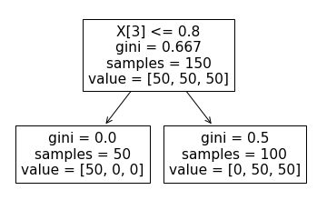

```python
from sklearn.tree import DecisionTreeClassifier as DTC
from sklearn.tree import plot_tree
from sklearn.datasets import load_iris

X,y=load_iris(return_X_y=True)

plot_tree(DTC(max_depth=1).fit(X,y));
```

# Boosting > Summary

- What are we going to see in this lecture?
  - Improving classification with boosting
  - How expressive is a classification boosting model?
  - Overfitting
  - AdaBoost in detail

# Boosting > AdaBoost classifier

- Notes:
  - Boosting increases expressiveness
  - Boosting has the power to improve the predictive ability of classifiers
  - Boosting may incur into overfitting (naturally)

# Boosting

- The standard boosting algorithm for classification is **AdaBoost.M1**
  - First a model is learned with the **original data**
  - Then the **error** of the single model is measured
  - The **weight of the model** in the ensemble increases with accuracy
  - The **weights of the misclassified** examples are higher
  - The process **iterates** but the only effort is in the **base learner**.
- Boosting works by
  - combining an **ensemble of basis functions,**
  - each **focused** on misclassified examples

# Boosting > AdaBoost classifier

- The standard boosting algorithm for classification is **AdaBoost.M1**
  - This is a **special case** of boosting
1. Initialize the weights of examples as $w_i = 1/N$
2. For M iterations
   - train classifier $G_m(x)$ using weights
   - compute error $err_m$ of this model (using weights)
   - compute the weight

     $$\beta_m = log\frac{1 - err_m}{err_m}$$
   - update weights

     $$w_i \leftarrow w_i \cdot \exp[\beta_m \cdot I(y_i \ne G_m(x_i))]$$
3. Output $G(x) = sign[\sum_{m=1}^M \beta_m G_m(x)]$

# Boosting > AdaBoost classifier

**Example**

- Start:
  - We have 10 cases
  - $w_i = 0.1~(i=1,\ldots,10)$
  - Learn a tree $T_1$
  - Cases 1 and 2 are misclassified
- **Weight update**:
  - $err_1 = 0.2$
  - $\beta_1=log((1-0.2)/0.2)=1.386$
  - $w_1 = w_2 = 0.1.\exp(1.386) = 0.39988$
  - $w_i (i>2) = 0.1$
- **Iteration 2**
  - Learn a tree using new weights
    - Weights affect computation of entropy and majority class
  - Calculate $\beta_2$
- **So far** the model is: $$ \beta_1.T_1 \oplus \beta_2.T_2 $$
- Where $\oplus$ represents the combination of trees by **weighted majority voting**

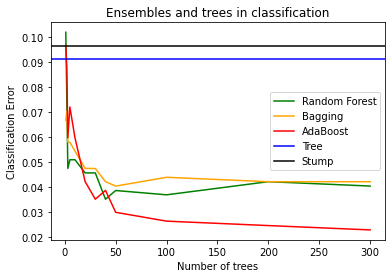

```python
from sklearn.datasets import load_breast_cancer
from sklearn.ensemble import AdaBoostClassifier as AdaC
from sklearn.tree import DecisionTreeClassifier as DTC
from sklearn.ensemble import RandomForestClassifier as RFC
from sklearn.ensemble import BaggingClassifier as BagC
from sklearn.model_selection import cross_val_score
import matplotlib.pyplot as plt

data=load_breast_cancer()
X=data.data
y=data.target

nfolds=5
RFfeat=np.int(np.sqrt(X.shape[1]))
ntree=np.array([1,2,3,5,10,20,30,40,50, 100, 200,300])


def score_ada_class(m):
    model=AdaC(n_estimators=m)
    return np.mean(1-cross_val_score(model,X,y,cv=nfolds))

def score_tree_class(depth=1):
    model=DTC(max_depth=depth)
    return np.mean(1-cross_val_score(model,X,y,cv=nfolds))

def score_rf_class(nt):
    model=RFC(n_estimators=nt, max_features=RFfeat)
    return np.mean(1-cross_val_score(model,X,y,cv=nfolds))

def score_bag_class(nt):
    model=BagC(n_estimators=nt)
    return np.mean(1-cross_val_score(model,X,y,cv=nfolds))


error_rf_class = list(map(score_rf_class,ntree))
error_bag_class = list(map(score_bag_class,ntree))
error_ada_class = list(map(score_ada_class,ntree))

error_tree = score_tree_class(None)
error_decision_stump = score_tree_class(1)

error_decision_stump

plt.plot(ntree,error_rf_class,color='green')
plt.plot(ntree,error_bag_class,color='orange')
plt.plot(ntree,error_ada_class,color='red')
plt.axhline(error_tree, color='blue')
plt.axhline(error_decision_stump, color='black')
plt.legend(['Random Forest','Bagging','AdaBoost','Tree','Stump'])
plt.xlabel('Number of trees')
plt.ylabel('Classification Error')
plt.title('Ensembles and trees in classification');
```

# Boosting > Beyond AdaBoost

- The **AdaBoost** (adaptive boosting) algorithm is a
  - **Forward Stagewise Additive Modeling** approach
- It keeps
  - **Adding** models,
  - **Stage by stage**,
  - And without revising previous decisions (**forward**)
    - meaning it uses a **gready** search strategy

# Boosting > Forward Stagewise Additive Modeling

- How is Forward Stagewise Additive Modeling defined **in general**?
  - Learn a first **basis function** $b(x;\theta_1)$ (e.g. a **tree?**)
  - Determine a weight $\beta_1$ for this model
  - Learn a second basis function $b(x;\theta_2)$ and weight $\beta_2$
  - Now the model is $\beta_1.b(x;\theta_1)+\beta_2.b(x;\theta_2)$
  - And iterate $M$ times
- The **final model** is:

  $$ f(x) = \sum_{i=1}^M \beta_i \cdot b(x;\theta_i) $$
- AdaBoost produces a model in this form

# Boosting > Forward Stagewise Additive Modeling

- How can we **learn** the ensemble model?
- At step $m$ we have $$f_m(x) = f_{m-1}(x) + \beta_m \cdot b(x;\theta_m)$$
- At step $m$ we have
  - The model learnt **so far** is $f_{m-1}(x)$,
  - FSAM (aka Boosting) learns a new **basis function** and estimates its weight in the ensemble.
  - I.e., it finds $b(x;\theta_m)$ and coefficient $\beta_m$ so that:
    - $b$ is a new **basis function** (for example a tree)
    - $\theta_m$ are **parameters** to learn at stage $m$

# Boosting > Forward Stagewise Additive Modeling > Learning

- How do we determine the weight $\beta$ and fit the basis function $b$ ?
  - **Minimize** $$\sum_{i} L(y_i, f_{m-1}(x_i) + \beta \cdot b(x_i; \theta_m))$$
  - over $\beta$ and $\theta_m$
  - In other words: **minimize the loss** in this iteration
    - Previous steps are not revisable (always go **forward**)
- **If** we can **solve** this minimization problem, we are done.
- Alternatively, we can **approximate**

# Boosting

- How is AdaBoost for classification a **special case** of FSAM?
  - It is, if the **exponential loss function** is used

$$ L(y, f(x)) = e^{-y~ f(x)} $$

- Next we see a sketch of how to demonstrate that

# Boosting > from FSAM to AdaBoost

- At each iteration $m$ we want to find $\beta$ and tree $T$ that minimize the exponential loss.

$$ (\beta_m, T_m) = \arg \min_{\beta,T} \sum_{i=1}^{N}{e^{-y_i (f_{m-1}(x_i) + \beta T(x_i))}} $$

- Let's work the **loss expression** we want to minimize
  - First **distribute** $\exp$ $$ L = \sum_{i=1}^{N}{e^{-y_i (f_{m-1}(x_i)}e^{-y_i\beta T(x_i))}} $$
- Now we will call $w_i^{(m)}$ to $e^{-y_i f_{m−1}(x_i)}$
  - And the expression becomes

$$ L = \sum_{i=1}^{N}{w_i^{(m)}.e^{-y_i\beta T(x_i))}} $$

- Since $-y_i T(x_i)$ is either $1$ (**hits**) or $-1$ (**misclassified**)

$$ L = \sum_{y_i=T(x_i)}{w_i^{(m)}.e^{-\beta}} + \sum_{y_i\neq T(x_i)}{w_i^{(m)}.e^{\beta}} $$

- Which can be **conveniently** transformed to

$$ L = \sum_{i=1}^{N}{w_i^{(m)}.e^{-\beta}} + \sum_{y_i\neq T(x_i)}^{N}{w_i^{(m)}.(e^{\beta}-e^{-\beta})} $$

- We see that only $\sum_{y_i\neq T(x_i)}^{N}w_i^{(m)}$ **depends** on $T$
  - And this is **the weak classifier with the lowest error**
  - Note that for decision stumps it is exhaustively searched
- Having $T$, to find the $\beta$ that minimizes $L$ we derive $L$ w.r.t. $\beta$
  - and solve $\partial{L}/\partial{\beta}=0$
  - and find:

$$ \beta_m = \frac{1}{2}\log\frac{1-err_m}{err_m} $$

[output not shown]

- And **this is AdaBoost**.

# Boosting

In summary:

- AdaBoost is **a form of boosting** for classification
- AdaBoost Classifier **can be derived from first principles** if exponential loss function is used

We will next see other forms of boosting

- In particular **gradient boosting**

# Boosting

**Variable Importance** in a tree

- Can be measured as error/impurity improvements of the variable in the tree
- If variable $X$ chosen for a node improves error in $v$, this is added to the importance of the variable

Variable importance in the ensemble

- Simply an average (normalized) over the set of trees
- In `sklearn` it is called `feature_importances_`

# Boosting

Notes (for AdaBoost in R):

- We can train each tree/model with a **subsample**. This makes the process more robust.
  - parameter `bag.fraction` choses the size of the bags for each iteration (default is 0.5)
  - parameter `train.fraction` chooses the size of the training subset and the remainder are for out-of-sample validation (default is 1)
- Sklearn uses the SAMME and SAMME.R algorithms for multiclass problems. Check how they work here: https://web.stanford.edu/~hastie/Papers/samme.pdf

# Bibliography

- The Elements of Statistical Learning. Hastie, Trevor, Tibshirani, Robert, Friedman, Jerome. Springer.
- Greedy function approximation: A gradient boosting machine. Friedman, Jerome H. Ann. Statist. 29 (2001), no. 5, 1189--1232. doi:10.1214/aos/1013203451. https://projecteuclid.org/euclid.aos/1013203451
- An Introduction to Statistical Learning - with applications in R G. James, D. Witten, T. Hastie, R. Tibshirani, Springer 2013.
- Gradient Boosting, from Wikipedia, the free encyclopedia
- AdaBoost Fits an Additive Model, Leon Gu, CMU. https://www.cs.cmu.edu/~epxing/Class/10701-08s/recitation/boosting.pdf
- AdaBoost#Derivation, wikipedia (English), https://en.wikipedia.org/wiki/AdaBoost#Derivation